# Praca domowa 2

Techniki wizualizacji danych

Piotr Wilczyński

31/10/2021

## Wstęp

Wykres przedstawia porównanie liczby morderstw w Stanach Zjednoczonych i Europie.

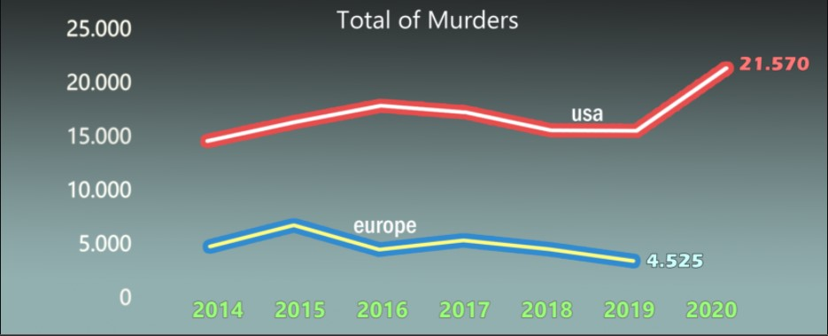

Został znaleziony na stronie:  
https://www.reddit.com/r/MapPorn/comments/pzy7wz/usa_and_europe_murder_rates_20202019/  
(dolny wykres)

Źródła podane przez autora wykresu:

- dane z UK: https://www.bbc.com/news/uk-50925024
- dane z większości krajów europejskich: https://appsso.eurostat.ec.europa.eu/nui/show.do?dataset=crim_off_cat&lang=en
- dane z USA: https://www.statista.com/statistics/191134/reported-murder-and-nonnegligent-manslaughter-cases-in-the-us-since-1990/

## Co z wykresem jest nie tak?

Oryginalny wykres miał być efektowny, a wyszedł nieczytelny. Nie ma w tyle siatki, która tworzyła by punkt odniesienia. Powoduje to, że na pierwszy rzut oka nie można odróżnić, czy więcej morderstw w Europie było w 2016, czy w 2018. Dodatkowo dla USA, wykres pokazuje dane do 2020 roku, a dla Europy do 2019. Podanie dokładnych wartości jedynie dla najnowszych danych, kiedy są one w innych latach, mija się z celem. Jeśli przyjrzy się nieuważnie, można wyciągnąć wnioski, że dla 2020 roku liczba morderstw w USA gwałtownie wzrosła, a w Europie nie. Należy jednak pamiętać, że są to wnioski pochopne, bo nie wiemy jak sytuacja wyglądała w Europie w 2020 roku. Wykres nie posiada także opisów osi.

## Poprawiony wykres

Poprawiony wykres został stworzony na podstawie danych podanych przez twórcę wykresu oryginalnego. W swoim wykresie dodałem siatkę, tak aby wykres był bardziej czytelny. Dodatkowo dodałem dokładne wartości dla każdego roku, tak aby łatwo było porównywać lata, w których liczba morderstw była podobna. Danych nie ma za dużo, więc nie obniża to czytelności wykresu. W porównaniu do oryginału, nie przedstawiałem danych dla USA z 2020 roku. Mija się to z celem, gdy nie mamy dostępu do informacji z Europy. Dodanie tych danych do wykresu może wprowadzić chaos i zmniejszyć jego czytelność. Dodatkowo dodałem opisy osi.

Podsumowując:

- dodana siatka
- dodane dokładne wartości dla każdego roku
- usunięcię danych z USA z 2020 roku
- dodanie opisów osi

Skrypt w R, tworzący poprawny wykres z oryginalnych danych:

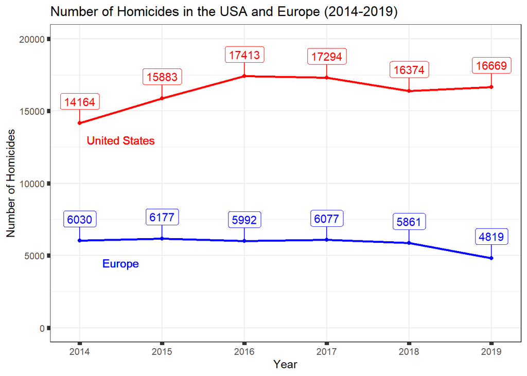

```r
# Piotr Wilczynski
# HW 2 - TWD, MiNI, PW
# 31.10.2021

# necessary libraries
library(dplyr)
library(ggplot2)
library(ggrepel)

# Europe
df_europe <- read.csv("crim_off_cat_1_Data.csv")

df_europe <- df_europe %>%
  filter(TIME >= 2014 &
          ICCS == "Intentional homicide" &
           UNIT == "Number" &
            Value != ":")

df_europe$Value <- as.integer(df_europe$Value)

df_europe <- df_europe %>%
  group_by(TIME) %>%
  summarize(homicides_number = sum(Value))

# UK 2014 - 2019
uk_homicides <- c(601, 611, 641, 728, 774, 650)
df_europe$homicides_number <- df_europe$homicides_number + uk_homicides

# US 2014 - 2019
df_US <- read.csv("US_homicide.csv")

# Merge
df_europe <- df_europe %>%
  mutate(region = "Europe")
df_US <- df_US %>%
  mutate(region = "United States")

df <- rbind(df_europe, df_US)

# Plot
ggplot(df, aes(x = TIME, y = homicides_number, group = region, color = region)) +
  geom_line(size = 1) +
  scale_y_continuous(limits = c(0, 20000)) +
  scale_x_continuous() +
  labs(
    title = "Number of Homicides in the USA and Europe (2014-2019)",
    x = "Year",
    y = "Number of Homicides"
  ) +
  scale_color_manual(values = c("blue", "red")) +
  geom_label_repel(label = df$homicides_number, min.segment.length = unit(0, 'lines'),
                   nudge_y = 1500) +
  geom_text(aes(x = 2014.5, y = 4500, label = "Europe", color = "Europe")) +
  geom_text(aes(x = 2014.5, y = 13000, label = "United States", color = "United States")) +
  geom_point() +
  theme_bw() +
  theme(
    legend.position = "None",
    panel.grid.major =  element_line(size = 0.5),
    panel.grid.minor.x = element_blank(),
    axis.ticks = element_line(size = 2)
  ) +
  expand_limits(x = c(2013.9, 2019.1))
```